# 2 Data

## 2.1 Technical Description

The original dataset, which describes all yellow taxi trips completed in 2014 in NYC, was downloaded on the NYC OpenData website ([link to dataset](https://data.cityofnewyork.us/Transportation/2014-Yellow-Taxi-Trip-Data/gkne-dk5s)). The data was collected and provided to the NYC Taxi and Limousine Commission (TLC) by technology providers authorized under the Taxicab Passenger Enhancement Program (TPEP). Thus, the trip data was not created by the TLC, and as explained on the agency website ([TLC website](https://www.nyc.gov/site/tlc/about/tlc-trip-record-data.page)), the TLC company cannot confirm the accuracy or completeness of these data. As a result, the data may differ from the total number of trips dispatched by all TLC-licensed bases in 2014.

The data was created on 06/03/2015, the data was last updated on 02/10/2016, and the metadata was last updated on 05/09/2022. The data is valuable for historical purposes, so its update frequency is set to *Historical Data*. The downloaded dataset is a .csv file containing 165 million rows and 19 columns. Each row corresponds to a yellow taxi trip completed in 2014 in NYC and is described by 19 attributes, including the vendor type, the pickup/dropoff time and geographic coordinates, the number of passengers, the trip distance, the fare amount, the tip amount, and others.

Given the substantial size of the dataset and our initial motivations, we chose to select a reduced sample of the data. From the NYC OpenData website, we only exported the taxi trips of November 2014, as we are interested in how special events like Thanksgiving and the NYC Marathon impact the trends. Moreover, the `payment_type` attribute that indicates how the passenger paid for the trip has six different levels: (1) Credit Card, (2) Cash, (3) No charge, (4) Dispute, (5) Unknown, and (6) Voided trip. The data shows that the first and second categories represent 92% of all taxi trips. We chose to filter out the other levels. The resulting dataset has around 12 million rows.

After some preliminary analysis, we noticed some issues with the data.

We identified around 4,600 trips with incoherent pickup and dropoff datetimes: either the two datetimes are the same, or the pickup datetime is later than the dropoff datetime. We removed those rows.

Given the NYC border longitudes and latitudes, there are 255,952 rows with incorrect geographic locations. We removed those rows.

Moreover, we plotted the relationship between the total amount of the trip and the trip distance. The corresponding scatter plot is shown below to highlight the outliers.

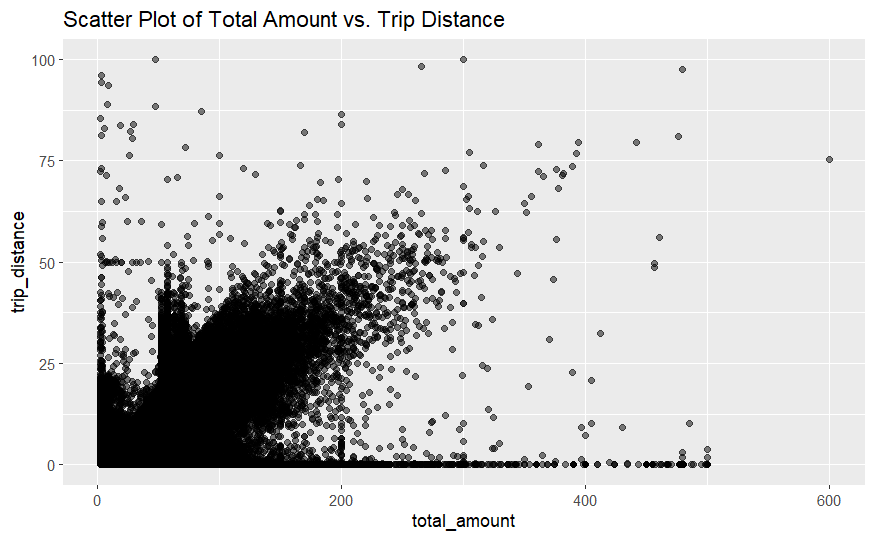

First, we noticed on the above plot that there are around 70,000 zero-distance rides. The pickup and dropoff geographic coordinates are roughly the same, while the total amount is non-zero and has to be at least 2.50$: the initial charge fare amount for yellow taxis equals 2.50$. We could infer that the dropoff location could not be tracked or that the trip was canceled. For our analysis, we removed those rows.

```r
head(data[data$trip_distance == 0])
```

```
   vendor_id     pickup_datetime    dropoff_datetime passenger_count
1:       CMT 2014-11-01 16:57:32 2014-11-01 16:58:21               1
2:       CMT 2014-11-01 05:48:01 2014-11-01 05:48:35               1
3:       CMT 2014-11-01 04:13:13 2014-11-01 04:13:34               2
4:       CMT 2014-11-01 21:35:36 2014-11-01 21:36:01               1
5:       CMT 2014-11-01 16:32:03 2014-11-01 16:38:39               2
6:       CMT 2014-11-01 09:07:47 2014-11-01 09:08:15               1
   trip_distance pickup_longitude pickup_latitude rate_code store_and_fwd_flag
1:             0        -73.93604        40.85468         5                  N
2:             0        -73.95223        40.77725         1                  N
3:             0        -73.95201        40.78138         5                  N
4:             0        -74.03833        40.73675         5                  N
5:             0        -74.00371        40.75323         0                  N
6:             0        -74.00156        40.72483         5                  N
   dropoff_longitude dropoff_latitude payment_type fare_amount surcharge
1:         -73.93612         40.85477          CRD        17.0       0.0
2:         -73.95223         40.77722          CRD         2.5       0.5
3:         -73.95205         40.78137          CRD        12.0       0.0
4:         -74.03833         40.73674          CRD        50.0       0.0
5:         -73.99257         40.76359          CRD         6.0       0.0
6:         -74.00155         40.72483          CRD        24.0       0.0
   mta_tax tip_amount tolls_amount total_amount
1:     0.0        0.0            0         17.0
2:     0.5        0.0            0          3.5
3:     0.0        3.6            0         15.6
4:     0.0       10.0            0         60.0
5:     0.5        1.0            0          7.5
6:     0.0        2.5            0         26.5
```

Second, we noticed rides with large distances and very low total fare amounts. As seen on the scatter plot, we can discard rides with more than 25 miles trip distances and close-to-zero trip total amounts. We don’t have enough information for other data points to decide whether they are outliers or not, so we chose to keep those observations.

We also observe that more than 1,500 trips involved 0 passengers. We chose to remove those rows as well.

## 2.2 Research Plan

The 19 attributes contained in the dataset with new variables will help us answer the research questions from the introduction. New variables include:

- trip duration in minutes (using pickup datatime and dropoff datetime columns)
- month, weekdays, hour of the day (using pickup datatime column)
- period of the day (using pickup datetime column)
- fare amount per mile in dollars/mile (using fare amount and trip distance columns)

We have at our disposal all the taxi trips in 2014 as well as the pickup times in datetime format. Using `lubridate` package, we are able to retrieve the month, day of the month, weekday, and hour of the pickup/dropoff datetimes. Those new columns are helpful to visualize the trends throughout different time scales. In particular, we may visualize the trend in the number of trips by day in November and identify whether weekends, holidays, or special events like the NYC Marathon may impact the number of trips.

Given the geographic coordinates (longitude and latitude) of pickup and dropoff locations, we are able to map the taxi trips. In particular, we may visualize the most and least busy pickup/dropoff locations on a NYC map. The datetime will also allow us to visualize how holidays and special events may impact the pickup/dropoff location distribution in the city. It would be interesting to visualize the business working hours by mapping the number of pickups/dropoffs between different periods of the day for a given location like the Financial District or World Trade Center Area.

Using the `fare_amount` attribute, we can visualize the overall distribution of the taxi fares across the different periods of the day and days of the week. Comparing the results for holidays and the results for usual days, we can determine whether the fares increase or decrease. It would be interesting to combine this attribute with the trip distance or the trip duration to identify whether there is a correlation between these variables.

Similarly, with the `tip_amount` column, we can study the tipping trend across different periods of the day and different days of the week. We can check if special events in the month affect the tipping behavior of passengers. Finally, we can compare the average tips for different pickup/dropoff locations using the longitude and latitude variables.

## 2.3 Missing value analysis

NYC Yellow Taxi Trip 2014 data do not have NA values (missing values).

- Check for total missing values

```r
cat("Count of total missing values: ", sum(is.na(data)))
```

```
Count of total missing values:  0
```

- Check for missing values by columns

```r
colSums(is.na(data)) |>
  sort(decreasing = TRUE)
```

```
         vendor_id    pickup_datetime   dropoff_datetime    passenger_count
                 0                  0                  0                  0
     trip_distance   pickup_longitude    pickup_latitude          rate_code
                 0                  0                  0                  0
store_and_fwd_flag  dropoff_longitude   dropoff_latitude       payment_type
                 0                  0                  0                  0
       fare_amount          surcharge            mta_tax         tip_amount
                 0                  0                  0                  0
      tolls_amount       total_amount
                 0                  0
```

- Plot: Patterns in Missing Values

```r
data <- data %>%
        rename("vendorId" = "vendor_id",
               "pickupT" = "pickup_datetime",
               "dropoffT" = "dropoff_datetime",
               "numPassengers" = "passenger_count",
               "distance" = "trip_distance",
               "pickupLon" = "pickup_longitude",
               "pickupLat" = "pickup_latitude",
               "rate" = "rate_code",
               "SFF" = "store_and_fwd_flag",
               "dropoffLon" = "dropoff_longitude",
               "dropoffLat" = "dropoff_latitude",
               "pay" = "payment_type",
               "fare" = "fare_amount",
               "surcharge" = "surcharge",
               "tax" = "mta_tax",
               "tip" = "tip_amount",
               "toll" = "tolls_amount",
               "total" = "total_amount")
```

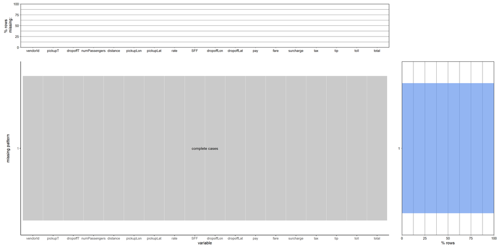

```r
library(redav)
plot_missing(data, percent = TRUE)
```

Nevertheless, all NA values from the data seem to have already been replaced with 0s (refer back to scatter plot in **2.1 data description** shown zero-distance trips with non-zero total amount).